# Michael Hornsby EDRM 878 Final

libraries:

NORMAL:

Description:

Mean-Variance Relationship:

The variance of mu can be treated as 1 here since the variance is captured in the dispersion parameter sigma squared, and the variance of a normal distribution is simply sigma squared

Dispersion:

The dispersion is sigma squared - the variance of a normal distribution, this will have to be estimated

Potential Link Functions:

identity, log, and inverse

Methods of Inference:

Useful because of relationships to t-distribution and chi-square distribution

Saddlepoint Approximation and Central Limit Theorem:

The saddlepoint approximation is exact for the normal distribution. The central limit theorem is exact for the normal distribution as well.

When to adjust for overdispersion:

Data cannot really be overdispered without infinite variance, but might need to be extra mindful of skew and kurtosis

What type of residual to use:

studentized and raw residuals should suffice

Diagnostics:

check for any skew or kurtosis outside of normal ranges, outliers, any points with high influence including cook’s D and dffits

Scale transformations to use:

Can use center and scaling (including standardizing), any of the link functions above, we can use a boxcox ladder of powers to check any transformations of the response necessary.

Analysis:

```r
data(crawl)

summary(crawl)
```

```
    BirthMonth      Age              SD          SampleSize         Temp
 April   :1    Min.   :28.58   Min.   :5.710   Min.   :21.00   Min.   :30.00
 August  :1    1st Qu.:30.35   1st Qu.:6.925   1st Qu.:26.75   1st Qu.:36.00
 December:1    Median :32.08   Median :7.185   Median :34.00   Median :50.00
 February:1    Mean   :31.77   Mean   :7.218   Mean   :34.50   Mean   :50.25
 January :1    3rd Qu.:33.36   3rd Qu.:7.725   3rd Qu.:44.00   3rd Qu.:63.75
 July    :1    Max.   :33.83   Max.   :8.330   Max.   :49.00   Max.   :73.00
 (Other) :6
```

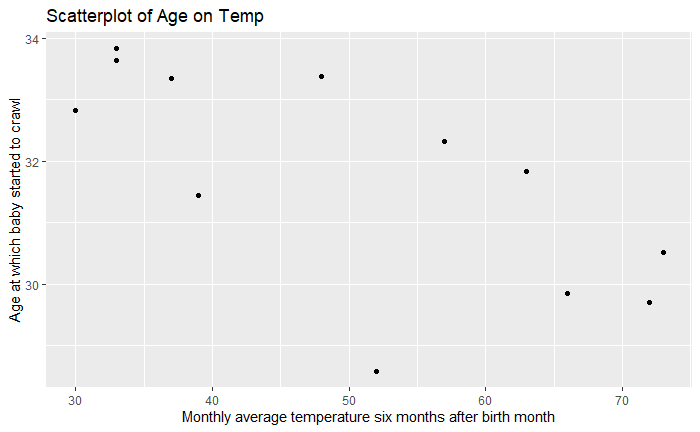

```r
crawl %>%
  ggplot(aes(x = Temp, y = Age)) +
  geom_point() +
  labs(title = "Scatterplot of Age on Temp",
       y = "Age at which baby started to crawl",
       x = "Monthly average temperature six months after birth month")
```

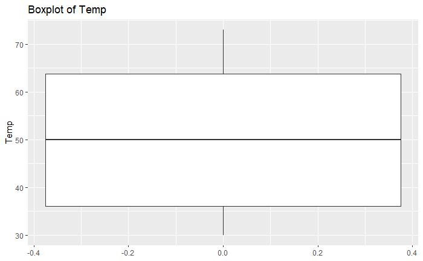

```r
crawl %>%
  ggplot(aes(y = Temp)) +
  geom_boxplot() +
  labs(title = "Boxplot of Temp")
```

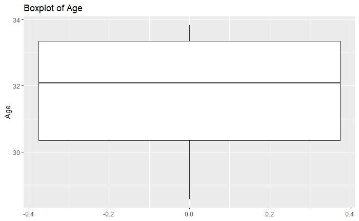

```r
crawl %>%
  ggplot(aes(y = Age)) +
  geom_boxplot() +
  labs(title = "Boxplot of Age")
```

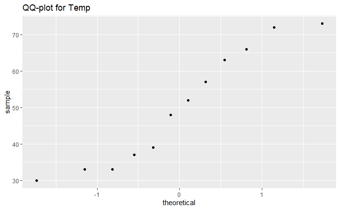

```r
crawl %>%
  ggplot() +
  geom_qq(aes(sample = Temp)) +
  labs(title = "QQ-plot for Temp")
```

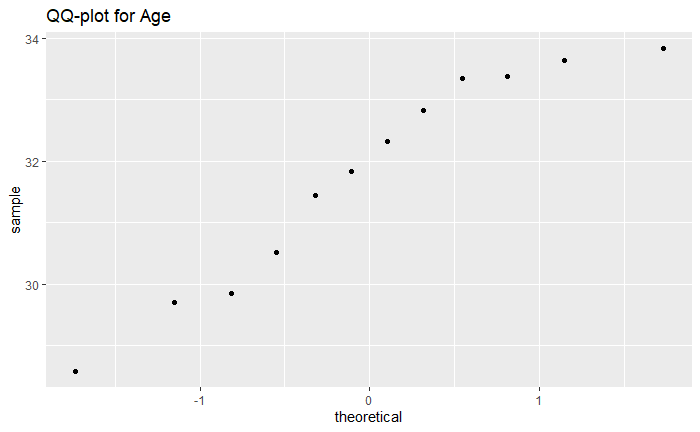

```r
crawl %>%
  ggplot() +
  geom_qq(aes(sample = Age)) +
  labs(title = "QQ-plot for Age")
```

Well, here we can see from the scatterplot that things look mostly linear. If I could remove that one observation around Temp 50 with the lowest Age, I would be extremely happy just using the two variables as they are. The boxplot for temp looks really good and mostly normal with a small skew. The boxplot for age looks as though it has much larger skew. The qq-plots mirror this. I’m going to try a ladder of powers with Age to see what I get and see if any transformation makes things better.

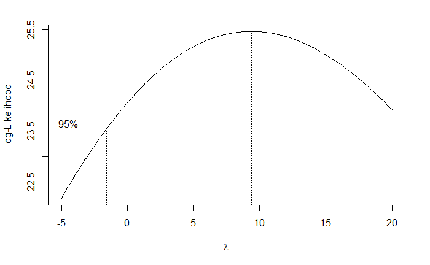

```r
boxcox(Age ~ Temp,
       lambda = seq(-5.00, 20.00, by = .05), data = crawl)
```

Oh boy, this doesn’t look good. Both our predictor and response show slight skew, and based on all of my exploration trying to transform the response, I think it is best to leave it as is. Twelve data points isn’t a lot and I wouldn’t expect a miracle from the model.

```r
normal.model <- glm(Age ~ Temp, data = crawl)
summary(normal.model)
```

```
Call:
glm(formula = Age ~ Temp, data = crawl)

Deviance Residuals:
    Min       1Q   Median       3Q      Max
-3.0556  -0.5712   0.5221   0.8029   1.4334

Coefficients:
            Estimate Std. Error t value Pr(>|t|)
(Intercept) 35.67806    1.31753  27.080 1.09e-10 ***
Temp        -0.07774    0.02510  -3.097   0.0113 *
---
Signif. codes:  0 ‘***’ 0.001 ‘**’ 0.01 ‘*’ 0.05 ‘.’ 0.1 ‘ ’ 1

(Dispersion parameter for gaussian family taken to be 1.740285)

    Null deviance: 34.096  on 11  degrees of freedom
Residual deviance: 17.403  on 10  degrees of freedom
AIC: 44.515

Number of Fisher Scoring iterations: 2
```

```r
confint(normal.model)
```

```
                 2.5 %      97.5 %
(Intercept) 33.0957562 38.26036294
Temp        -0.1269348 -0.02854351
```

Ok, all things considered, this model looks nice. We have a significant p-value of 0.0113 for Temp, which is significant at an alpha = 0.05 level. We have an Intercept age of 35.67806 and a Temp coefficient of -0.07774. Thus our model is:

Age = 35.67806 - 0.07774(Temp) + e

This model will give us the expected Age at which the baby will start to crawl given the monthly average temperature six months after the birth month of the baby.

We have our 95% confidence interval for the Intercept: (33.0957562, 38.26036294) And our 95% confidence interval for the Temp coefficient: (-0.1269348, -0.02854351)

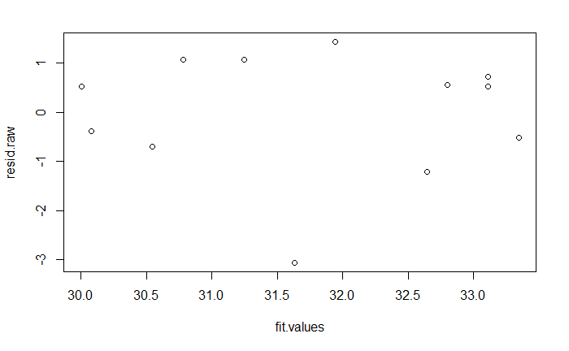

```r
resid.raw <- resid(normal.model)

fit.values <- fitted(normal.model)

plot(fit.values, resid.raw)
```

```r
influence.measures(normal.model)
```

```
Influence measures of
     glm(formula = Age ~ Temp, data = crawl) :
```

|  | dfb.1_ | dfb.Temp | dffit | cov.r | cook.d | hat | inf |
| --- | --- | --- | --- | --- | --- | --- | --- |
| 1 | 0.12737778 | -0.18762832 | -0.2605226 | 1.3910712 | 0.03639585 | 0.17313784 |  |
| 2 | -0.17048714 | 0.22298865 | 0.2680276 | 1.6222964 | 0.03907027 | 0.27070323 | * |
| 3 | 0.11555126 | -0.15290774 | -0.1864340 | 1.6194049 | 0.01909390 | 0.25459318 | * |
| 4 | -0.13743513 | 0.22406565 | 0.3482757 | 1.2308943 | 0.06231945 | 0.14218481 |  |
| 5 | -0.19233670 | -0.12420196 | -1.0839300 | 0.2311222 | 0.27023167 | 0.08444203 | * |
| 6 | -0.30209609 | 0.22425284 | -0.3765021 | 1.1585200 | 0.07119144 | 0.12915196 |  |
| 7 | 0.18828050 | -0.15540620 | 0.2069633 | 1.4664549 | 0.02332651 | 0.19105801 |  |
| 8 | -0.22499551 | 0.19166897 | -0.2394978 | 1.5412619 | 0.03120704 | 0.23178568 |  |
| 9 | 0.25834184 | -0.21323463 | 0.2839767 | 1.4166244 | 0.04316399 | 0.19105801 |  |
| 10 | 0.15165425 | -0.11771802 | 0.1789602 | 1.3891281 | 0.01743236 | 0.14689112 |  |

[output cut: 2 more lines]

As far as diagnostics go, the residual plot looks to have an even enough spread with the exception of that one point. R marks 3 obserations as highly influential. I wouldn’t be concerned with observations 2 and 3. They have low cook’s D. However, again, that one observation that seems to be an outlier has a significantly higher cook’s D relative to the rest of the observations. I think I would suggest returning to the theory or researcher on how to address this point. The model holds when including it, but removing it may be acceptable. Also, more than 12 data points would be nice as well. However, regardless of this highly influential point, we can safely conclude that Temp does significantly predict Age in the context of these variables.

Plot of model relationship:

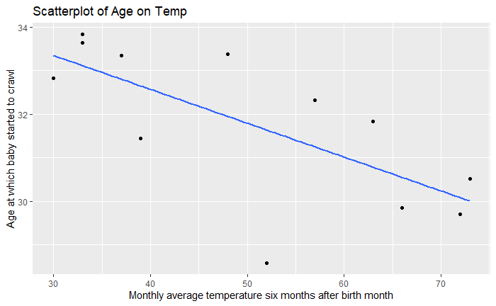

```r
crawl %>%
  ggplot(aes(x = Temp, y = Age)) +
  geom_point() +
  labs(title = "Scatterplot of Age on Temp",
       y = "Age at which baby started to crawl",
       x = "Monthly average temperature six months after birth month") +
  geom_smooth(method = 'lm', se = FALSE)
```

Additional:

Our Wald test is the same as above:

```r
summary(glm(Age ~ Temp, data = crawl))
```

```
Call:
glm(formula = Age ~ Temp, data = crawl)

Deviance Residuals:
    Min       1Q   Median       3Q      Max
-3.0556  -0.5712   0.5221   0.8029   1.4334

Coefficients:
            Estimate Std. Error t value Pr(>|t|)
(Intercept) 35.67806    1.31753  27.080 1.09e-10 ***
Temp        -0.07774    0.02510  -3.097   0.0113 *
---
Signif. codes:  0 ‘***’ 0.001 ‘**’ 0.01 ‘*’ 0.05 ‘.’ 0.1 ‘ ’ 1

(Dispersion parameter for gaussian family taken to be 1.740285)

    Null deviance: 34.096  on 11  degrees of freedom
Residual deviance: 17.403  on 10  degrees of freedom
AIC: 44.515

Number of Fisher Scoring iterations: 2
```

The score test:

```r
crawl.m0 <- glm(Age ~ 1, data = crawl)
z.stat <- glm.scoretest(crawl.m0, crawl$Temp)
p.val <- 2 * pnorm(abs(z.stat), lower.tail = FALSE)
round(c(score.stat = z.stat, P = p.val), 4)
```

```
score.stat          P
   -2.3207     0.0203
```

The likelihood ratio test:

```r
fit <- glm(Age ~ Temp, data = crawl)
as.data.frame(anova(fit, test = "Chisq"))
```

|  | Df | Deviance | Resid. Df | Resid. Dev | Pr(>Chi) |
| --- | --- | --- | --- | --- | --- |
| NULL | NA | NA | 11 | 34.09617 | NA |
| Temp | 1 | 16.69332 | 10 | 17.40285 | 0.001953959 |

Well, all 3 tests suggest that Temp does have a significant effect on Age. The p-values differ, especially for the likelihood ratio test, but I think this is most likely because of the smaller sample size.

BINOMIAL:

Description:

Mean-Variance Relationship:

For mean mu, the variance will be: V(mu) = mu(1 - mu) where mu = np

Dispersion:

The dispersion is 1/m where m in the number of trials

Potential Link Functions:

logit, probit, cauchit, log, and cloglog

Methods of Inference:

can use logistic regression when appropriate, also can use weights. We can calculate the median effective dose (ed50 as an example) Cannot use goodness-of-fit for binary responses

Saddlepoint Approximation and Central Limit Theorem:

The saddlepoint approximation for the binomial will be sufficient when min(my) >= 3 and min(m(1-y)) >= 3 The central limit theorem will be sufficiently accurate for the binomial when min(my) >= 5 and min(m(1-y)) >= 5

When to adjust for overdispersion:

When variance of the data exceeds mu(1 - mu), there is evidence of possible overdispersion Can use the quasi-binomial to adjust if needed

What type of residual to use:

residuals should be normal around the fitted values.

Diagnostics:

influence measures including dffits and cook’s D residuals should be normal around fit values.

Analysis:

```r
data(belection)

belection$totalran = belection$Females + belection$Males
belection$propfemale <- belection$Females / (belection$total)
belection$Region <- as.factor(belection$Region)
belection$Party <- as.factor(belection$Party)

summary(belection)
```

```
           Region      Party       Females           Males           totalran
 NorthWest    :10   Cons  :11   Min.   : 0.000   Min.   :  6.00   Min.   :  7.00
 EastAnglia   : 5   Green :11   1st Qu.: 4.000   1st Qu.: 22.00   1st Qu.: 27.50
 EastMidlands : 5   Labour:11   Median : 8.000   Median : 37.00   Median : 48.00
 GreaterLondon: 5   LibDem:11   Mean   : 9.345   Mean   : 42.16   Mean   : 51.51
 Scotland     : 5   Other :11   3rd Qu.:12.500   3rd Qu.: 59.00   3rd Qu.: 72.00
 SouthEast    : 5               Max.   :28.000   Max.   :101.00   Max.   :114.00
 (Other)      :20
   propfemale
 Min.   :0.0000
 1st Qu.:0.1156
 Median :0.1852
 Mean   :0.1828
 3rd Qu.:0.2534
 Max.   :0.4000
```

We’re going to be using a binomial EDM with a logit link and we have region and party to explore.

```r
binom.logit <- glm(Females/totalran ~ Party,
                data = belection,
                family = binomial,
                weights = totalran)

summary(binom.logit)
```

```
Call:
glm(formula = Females/totalran ~ Party, family = binomial, data = belection,
    weights = totalran)

Deviance Residuals:
     Min        1Q    Median        3Q       Max
-3.08723  -0.83037   0.01413   0.70980   2.64876

Coefficients:
            Estimate Std. Error z value Pr(>|z|)
(Intercept)  -2.3148     0.1388 -16.672  < 2e-16 ***
PartyGreen    1.1516     0.2029   5.677 1.37e-08 ***
PartyLabour   0.9206     0.1708   5.389 7.08e-08 ***
PartyLibDem   1.0209     0.1693   6.032 1.62e-09 ***
PartyOther    0.9174     0.1689   5.433 5.54e-08 ***
---
Signif. codes:  0 ‘***’ 0.001 ‘**’ 0.01 ‘*’ 0.05 ‘.’ 0.1 ‘ ’ 1

(Dispersion parameter for binomial family taken to be 1)

    Null deviance: 115.316  on 54  degrees of freedom
Residual deviance:  60.824  on 50  degrees of freedom
AIC: 266.61

Number of Fisher Scoring iterations: 4
```

```r
anova(binom.logit, test = "Chisq")
```

```
Analysis of Deviance Table

Model: binomial, link: logit

Response: Females/totalran

Terms added sequentially (first to last)

      Df Deviance Resid. Df Resid. Dev  Pr(>Chi)
NULL                     54    115.316
Party  4   54.492        50     60.824 4.152e-11 ***
---
Signif. codes:  0 ‘***’ 0.001 ‘**’ 0.01 ‘*’ 0.05 ‘.’ 0.1 ‘ ’ 1
```

```r
confint(binom.logit)
```

```
                 2.5 %    97.5 %
(Intercept) -2.5975764 -2.052300
PartyGreen   0.7541182  1.550846
PartyLabour  0.5906186  1.261396
PartyLibDem  0.6943057  1.358877
PartyOther   0.5916228  1.254698
```

Well, after factoring in the weights and our 2 factor predictors, Party and Region, I settled on the model above. The model is a weighted logistic regression using only Party as a predictor. Party has a significant p-value of 4.152 x 10^(-11), which is significant at any reasonable alpha level. In terms of the parties, this model results in the following expected proportions of females running:

Conservative: 0.0899 Green: 0.2381 Labour: 0.1987 LibDem: 0.2152 Other: 0.1982

as shown below:

```r
exp(-2.3148)/(1 + exp(-2.3148))
```

```
[1] 0.08990463
```

```r
exp(-2.3148 + 1.1516)/(1 + exp(-2.3148 + 1.1516))
```

```
[1] 0.2380863
```

```r
exp(-2.3148 + 0.9206)/(1 + exp(-2.3148 + 0.9206))
```

```
[1] 0.1987381
```

```r
exp(-2.3148 + 1.0209)/(1 + exp(-2.3148 + 1.0209))
```

```
[1] 0.2151934
```

```r
exp(-2.3148 + 0.9174)/(1 + exp(-2.3148 + 0.9174))
```

```
[1] 0.198229
```

The 95% confidence intervals for these coefficients are noted above.

Let’s look at diagnostics:

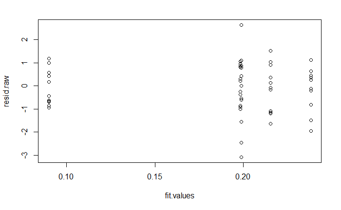

```r
resid.raw <- resid(binom.logit)

fit.values <- fitted(binom.logit)

plot(fit.values, resid.raw)
```

```r
influence.measures(binom.logit)
```

```
Influence measures of
     glm(formula = Females/totalran ~ Party, family = binomial, data = belection,      weights = totalran) :
```

|  | dfb.1_ | dfb.PrtG | dfb.PrtL | dfb.PrLD | dfb.PrtO | dffit | cov.r | cook.d | hat | inf |
| --- | --- | --- | --- | --- | --- | --- | --- | --- | --- | --- |
| 1 | -2.800376e-01 | 1.916639e-01 | 2.276032e-01 | 2.297225e-01 | 2.302461e-01 | -0.280037632 | 1.2856566 | 1.821047e-02 | 0.17192429 |  |
| 2 | -1.875834e-01 | 1.283862e-01 | 1.524601e-01 | 1.538797e-01 | 1.542305e-01 | -0.187583353 | 1.1457953 | 7.809180e-03 | 0.07570978 |  |
| 3 | 6.380614e-02 | -4.367033e-02 | -5.185904e-02 | -5.234190e-02 | -5.246122e-02 | 0.063806135 | 1.2717894 | 1.027969e-03 | 0.13249211 |  |
| 4 | -1.117416e-01 | 7.647842e-02 | 9.081904e-02 | 9.166466e-02 | 9.187362e-02 | -0.111741597 | 1.0986750 | 2.618381e-03 | 0.03154574 |  |
| 5 | -1.072611e-01 | 7.341183e-02 | 8.717743e-02 | 8.798915e-02 | 8.818973e-02 | -0.107261053 | 1.1653666 | 2.662903e-03 | 0.06624606 |  |
| 6 | -2.035360e-01 | 1.393045e-01 | 1.654258e-01 | 1.669661e-01 | 1.673467e-01 | -0.203535970 | 1.1018127 | 8.752432e-03 | 0.05993691 |  |
| 7 | 3.403881e-01 | -2.329691e-01 | -2.766536e-01 | -2.792296e-01 | -2.798661e-01 | 0.340388106 | 1.1389627 | 3.132716e-02 | 0.11356467 |  |
| 8 | 3.615992e-01 | -2.474865e-01 | -2.938932e-01 | -2.966296e-01 | -2.973059e-01 | 0.361599227 | 1.0684167 | 3.624140e-02 | 0.09148265 |  |
| 9 | -2.724192e-01 | 1.864497e-01 | 2.214113e-01 | 2.234728e-01 | 2.239823e-01 | -0.272419190 | 1.1155558 | 1.584993e-02 | 0.08517350 |  |
| 10 | 1.968655e-01 | -1.347391e-01 | -1.600043e-01 | -1.614941e-01 | -1.618623e-01 | 0.196865515 | 1.2129337 | 1.016669e-02 | 0.11514196 |  |

[output cut: 45 more lines]

I looked through all of the points marked as influential, but they all look ok. Cook’s D’s all look good, and the residuals show a nice, mostly even spread about 0.  
I think this is a nice model altogether. I’m actually big on following politics including UK politics, and this seems to follow the trend I would expect from these parties. I think it is interesting to note that this was coming out of Margaret Thatcher’s tenure as Prime Minister which ended in 1990, and she was the first female PM and a member of the Conservative party, so I was curious if her leadership would bring female Conservative participation up to a level even with the other parties. Also a random note: the Green party in the UK has only ever had one member of parliament elected to the House of Commons, who is female. Her name is Caroline Lucas and she’s been an mp since 2010, so it is interesting that Greens have the highest expected proportion of female participation here.

Additional:

1. We can conduct a goodness-of-fit test

```r
c(Df = df.residual(binom.logit),
  Resid.dev = deviance(binom.logit),
  Pearson.X2 = sum(resid(binom.logit, type = "pearson")^2))
```

```
        Df  Resid.dev Pearson.X2
  50.00000   60.82430   56.02685
```

These are different, but I wouldn’t feel comfortable saying they are significantly different. We want these 3 numbers to be close, and I would say they are sufficiently close enough to not worry about overdispersion.

3. To handle any overdispersion, we could shift from using a binomial model to a quasi-binomial model.

POISSON:

Description:

Mean-Variance Relationship:

The mean equals the variance in a poisson distribution

Dispersion:

The dispersion parameter equals 1 for the poisson

Potential Link Functions:

log, identity, and sqrt

Methods of Inference:

Useful when modeling response as count or can be treated as rates Also can do log-linear analysis when we have the appropriate contingency table format

Saddlepoint Approximation and Central Limit Theorem:

The saddlepoint approximation for the poisson will be sufficient when min(y) >= 3 The central limit theorem will be sufficiently accurate for the poisson when min(y) >= 5

When to adjust for overdispersion:

Adjust for overdispersion when var(y) > mu, as the assumption for the poisson is that the var(y) = mu can use a quasi-poisson when appropriate

What type of residual to use:

residuals should be normal around fitted values

Diagnostics:

influence measures including dffits and cook’s D Also, be wary of Simpson’s paradox

Analysis:

First I want to load the data, create the contingency table, and look at the counts:

```r
load(here("data","sociology.Rdata"))

soc_survey$response <- as.factor(soc_survey$response)
soc_survey$major <- as.factor(soc_survey$major)
soc_survey$gender <- as.factor(soc_survey$gender)

summary(soc_survey)
```

```
 response major  gender
 1:16     1:79   1:82
 2:36     2:81   2:78
 3:50
 4:58
```

```r
table(soc_survey)
```

```
, , gender = 1

        major
response  1  2
       1  1  5
       2  6 16
       3 16  8
       4 20 10

, , gender = 2

        major
response  1  2
       1  0 10
       2  2 12
       3 19  7
       4 15 13
```

```r
Count <- c(1, 5, 6, 16, 16, 8, 20, 10, 0, 10, 2, 12, 19, 7, 15, 13)
Response <- c(1, 1, 2, 2, 3, 3, 4, 4, 1, 1, 2, 2, 3, 3, 4, 4)
Major <- c(1, 2, 1, 2, 1, 2, 1, 2, 1, 2, 1, 2, 1, 2, 1, 2)
Gender <- c(1, 1, 1, 1, 1, 1, 1, 1, 2, 2, 2, 2, 2, 2, 2, 2)
soctable <- data.frame(Count, Response, Major, Gender)
soctable
```

| Count | Response | Major | Gender |
| --- | --- | --- | --- |
| 1 | 1 | 1 | 1 |
| 5 | 1 | 2 | 1 |
| 6 | 2 | 1 | 1 |
| 16 | 2 | 2 | 1 |
| 16 | 3 | 1 | 1 |
| 8 | 3 | 2 | 1 |
| 20 | 4 | 1 | 1 |
| 10 | 4 | 2 | 1 |
| 0 | 1 | 1 | 2 |
| 10 | 1 | 2 | 2 |

[output cut: 6 more lines]

Let’s check the interaction of response and major to see what happens:

```r
poisson.1 <- glm(Count ~ Response * Major,
            family = poisson,
            data = soctable)

anova(poisson.1, test = "Chisq")
```

```
Analysis of Deviance Table

Model: poisson, link: log

Response: Count

Terms added sequentially (first to last)

               Df Deviance Resid. Df Resid. Dev  Pr(>Chi)
NULL                              15     72.890
Response        1   24.942        14     47.947 5.907e-07 ***
Major           1    0.025        13     47.922    0.8744
Response:Major  1   20.443        12     27.480 6.144e-06 ***
---
Signif. codes:  0 ‘***’ 0.001 ‘**’ 0.01 ‘*’ 0.05 ‘.’ 0.1 ‘ ’ 1
```

We see that sociology students do differ significantly in response counts. Let’s look at a table to see:

```r
table(soc_survey$response, soc_survey$major)
```

```
     1  2
  1  1 15
  2  8 28
  3 35 15
  4 35 23
```

We can see that sociology students are more likely to choose options 3 and 4 (increase social services support or none of the above) and that other majors are more likely to choose options 1 and 2 in comparison to sociology students (increasing penalties and police force).

Let’s explore factoring in gender:

```r
poisson.2 <- glm(Count ~ Response * Major * Gender,
            family = poisson,
            data = soctable)

anova(poisson.2, test = "Chisq")
```

```
Analysis of Deviance Table

Model: poisson, link: log

Response: Count

Terms added sequentially (first to last)

                      Df Deviance Resid. Df Resid. Dev  Pr(>Chi)
NULL                                     15     72.890
Response               1  24.9423        14     47.947 5.907e-07 ***
Major                  1   0.0250        13     47.922    0.8744
Gender                 1   0.1000        12     47.822    0.7518
Response:Major         1  20.4427        11     27.380 6.144e-06 ***
Response:Gender        1   0.0270        10     27.353    0.8695
Major:Gender           1   0.6191         9     26.734    0.4314
Response:Major:Gender  1   0.1779         8     26.556    0.6732
---
Signif. codes:  0 ‘***’ 0.001 ‘**’ 0.01 ‘*’ 0.05 ‘.’ 0.1 ‘ ’ 1
```

```r
poisson.3 <- glm(Count ~ Response * Major * Gender - Response:Major:Gender,
            family = poisson,
            data = soctable)

anova(poisson.3, test = "Chisq")
```

```
Analysis of Deviance Table

Model: poisson, link: log

Response: Count

Terms added sequentially (first to last)

                Df Deviance Resid. Df Resid. Dev  Pr(>Chi)
NULL                               15     72.890
Response         1  24.9423        14     47.947 5.907e-07 ***
Major            1   0.0250        13     47.922    0.8744
Gender           1   0.1000        12     47.822    0.7518
Response:Major   1  20.4427        11     27.380 6.144e-06 ***
Response:Gender  1   0.0270        10     27.353    0.8695
Major:Gender     1   0.6191         9     26.734    0.4314
---
Signif. codes:  0 ‘***’ 0.001 ‘**’ 0.01 ‘*’ 0.05 ‘.’ 0.1 ‘ ’ 1
```

```r
poisson.4 <- glm(Count ~ Response * Gender,
            family = poisson,
            data = soctable)

anova(poisson.4, test = "Chisq")
```

```
Analysis of Deviance Table

Model: poisson, link: log

Response: Count

Terms added sequentially (first to last)

                Df Deviance Resid. Df Resid. Dev  Pr(>Chi)
NULL                               15     72.890
Response         1  24.9423        14     47.947 5.907e-07 ***
Gender           1   0.1000        13     47.847    0.7518
Response:Gender  1   0.0282        12     47.819    0.8665
---
Signif. codes:  0 ‘***’ 0.001 ‘**’ 0.01 ‘*’ 0.05 ‘.’ 0.1 ‘ ’ 1
```

I tried the above 3 models, as well as some additional ones just to be safe, and found no indication that Gender has any effect on response count. I think it is worth mentioning that some count cells do have low values (including 1 and 0), however, I don’t think that is cause for alarm here given the context of the situation and sample size.

Additional:

I don’t think we have to worry about simpson’s paradox in this data, especially with regards to the specific research question of interest. Looking at the counts of response by major pretty much explains our significant effect there. I suppose it is still possible for the paradox to occur in some effect given we can’t randomize to condition here, but I’m not seeing any real evidence of it, especially since in this reasearch question of interest we don’t want to look at just reponse variable counts alone.

GAMMA:

Description:

Mean-Variance Relationship:

The variance of mu for the gamma edm is mu squared

Dispersion:

Unless y follows a normal or exponential distribution, the dispersion parameter will have to be estimated. Thus, the likelihood ratio tests are based on F-tests

Potential Link Functions:

inverse, identity, and log

Methods of Inference:

Useful when we have a positive, continuous response (Also has a relationship to the exponential distribution)

Saddlepoint Approximation and Central Limit Theorem:

The saddlepoint approximation for the gamma will be sufficiently accurate when phi <= 1/3 The central limit theorem for the gamma will be sufficiently accurate when phi <= 1/5

When to adjust for overdispersion:

shouldn’t need to adjust for overdispersion as the dispersion parameter should capture the adjustment needed (hope I’m saying that right)

What type of residual to use:

residuals should be normal around fitted values.

Diagnostics:

influence measures (including dffits and cook’s D)

Analysis:

Import data and subset to only include Trial 1:

```r
data(blocks)

blocks$Trial <- as.factor(blocks$Trial)
blocks$Shape <- as.factor(blocks$Shape)

blockst1 <- subset(blocks, Trial == 1)

summary(blockst1)
```

```
     Child        Number           Time        Trial       Shape         Age
 A      : 2   Min.   : 3.00   Min.   :  6.00   1:50   Cube    :25   Min.   :2.420
 B      : 2   1st Qu.: 5.00   1st Qu.: 14.25   2: 0   Cylinder:25   1st Qu.:3.670
 C      : 2   Median : 6.00   Median : 20.40                        Median :4.000
 D      : 2   Mean   : 6.74   Mean   : 29.58                        Mean   :4.026
 E      : 2   3rd Qu.: 8.00   3rd Qu.: 33.40                        3rd Qu.:4.580
 F      : 2   Max.   :13.00   Max.   :178.00                        Max.   :5.080
 (Other):38
```

I want to plot the relationships:

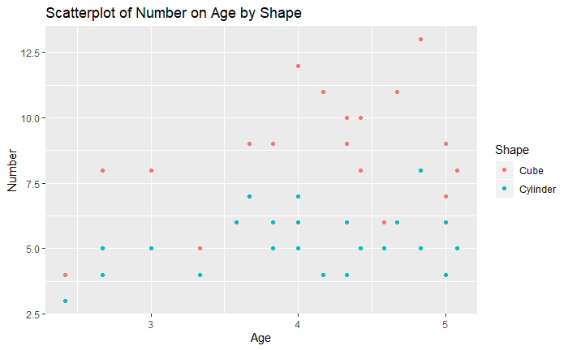

```r
blockst1 %>%
  ggplot(aes(x = Age, y = Number, color = Shape)) +
  geom_point() +
  labs(title = "Scatterplot of Number on Age by Shape",
       y = "Number",
       x = "Age")
```

Looking at this, it does look as though shape is significant and there does appear to be some upward trend. There does seem to be more spread in higher ages, which suggests I might want to start with a log link. Let’s look at the model:

```r
gamma.glm <- glm(Number ~  Age + Shape,
                family = Gamma(link = "log"),
                data = blockst1)

summary(gamma.glm)
```

```
Call:
glm(formula = Number ~ Age + Shape, family = Gamma(link = "log"),
    data = blockst1)

Deviance Residuals:
     Min        1Q    Median        3Q       Max
-0.45539  -0.17121  -0.03617   0.16120   0.42322

Coefficients:
              Estimate Std. Error t value Pr(>|t|)
(Intercept)    1.45642    0.18314   7.953 3.00e-10 ***
Age            0.15828    0.04402   3.596 0.000773 ***
ShapeCylinder -0.43167    0.06526  -6.615 3.14e-08 ***
---
Signif. codes:  0 ‘***’ 0.001 ‘**’ 0.01 ‘*’ 0.05 ‘.’ 0.1 ‘ ’ 1

(Dispersion parameter for Gamma family taken to be 0.05323401)

    Null deviance: 5.5821  on 49  degrees of freedom
Residual deviance: 2.5650  on 47  degrees of freedom
AIC: 187.04

Number of Fisher Scoring iterations: 5
```

```r
confint(gamma.glm)
```

```
                   2.5 %     97.5 %
(Intercept)    1.0832613  1.8377776
Age            0.0673857  0.2480577
ShapeCylinder -0.5597217 -0.3036244
```

I started by including an interaction effect, but I removed it and the model looks a lot better. We can see that both predictors have p-values significant at any reasonable alpha level. Also, the 95% confidence intervals are included above. The model above:

log(Number) = 1.45642 + 0.15828(Age) - 0.43167(I = ShapeCylinder) + e

This suggests that as Age increases, so does the number of blocks used. This also suggests that when the blocks are shaped as cylinders, children use less blocks.

Let’s look at residuals:

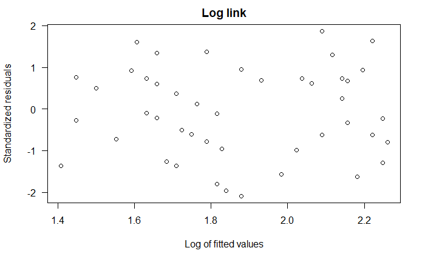

```r
plot(rstandard(gamma.glm) ~ log(fitted(gamma.glm)),
     main = "Log link",
     las = 1,
     xlab = "Log of fitted values",
     ylab = "Standardized residuals")
```

I think this residual plot looks good given the data. It does seem to have a fairly even spread about 0. I certainly don’t see any apparent problematic trends. Let’s check for any highly influential points:

```r
influence.measures(gamma.glm)
```

```
Influence measures of
     glm(formula = Number ~ Age + Shape, family = Gamma(link = "log"),      data = blockst1) :
```

|  | dfb.1_ | dfb.Age | dfb.ShpC | dffit | cov.r | cook.d | hat | inf |
| --- | --- | --- | --- | --- | --- | --- | --- | --- |
| 1 | -0.064794551 | 0.116262156 | -0.13390924 | 0.22221669 | 1.0686750 | 0.0194174813 | 0.05507598 |  |
| 2 | 0.029716630 | -0.042670196 | 0.03248870 | -0.06270388 | 1.1488433 | 0.0013260184 | 0.07449965 |  |
| 3 | 0.007482598 | -0.025225386 | 0.04750846 | -0.07176648 | 1.1098396 | 0.0017053250 | 0.04563850 |  |
| 4 | -0.001402567 | 0.014358036 | -0.03505754 | 0.05161604 | 1.1107214 | 0.0009641681 | 0.04335473 |  |
| 5 | -0.004161741 | 0.042603622 | -0.10402386 | 0.15315677 | 1.0781793 | 0.0090282462 | 0.04335473 |  |
| 6 | -0.166353103 | 0.260320940 | -0.24013606 | 0.42789911 | 0.9598338 | 0.0764465430 | 0.06350355 |  |
| 7 | -0.014917352 | 0.050289480 | -0.09471315 | 0.14307408 | 1.0870239 | 0.0078173604 | 0.04563850 |  |
| 8 | 0.173186799 | -0.248679430 | 0.18934224 | -0.36543457 | 1.0362933 | 0.0369863073 | 0.07449965 |  |
| 9 | -0.132834155 | 0.085179367 | 0.14144853 | -0.21741871 | 1.0527438 | 0.0139002963 | 0.04725274 |  |
| 10 | 0.107156427 | -0.009765179 | -0.27419813 | 0.38789764 | 0.8858466 | 0.0639506210 | 0.04002537 |  |

[output cut: 40 more lines]

Everything looks alright here, the one point marked as influential checks out as ok as far as I can tell.

I hope I was sufficient here, I felt like this was a fairly straightforward analysis going into it knowing to use a gamma glm.

Additional:

```r
blockst1$Agegrp <- cut(blockst1$Age, breaks = 3)
```

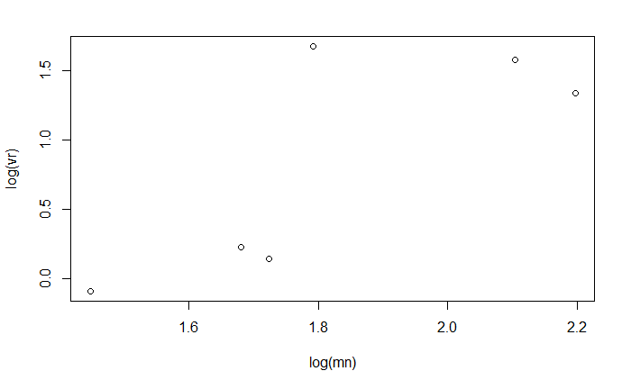

```r
vr <- with(blockst1, tapply(Number, list(Agegrp, Shape), "var"))
mn <- with(blockst1, tapply(Number, list(Agegrp, Shape), "mean"))
plot(log(vr) ~ log(mn))
```

The goal here is to show that as mean increases, so does the variance. I think this plot sufficiently shows that. I was expecting a quadratic relationship here, and I think I see one, but I was thinking it might be more apparent.